# **Questão 1: Criando o cluster spark.**

## **c)** Crie uma conexão *Spark*, carregue para ele os dados em formato *.parquet* e *.csv* e compare os respectivos tempos computacionais. Se desejar, importe apenas as colunas necessárias para realizar a Questão2.

**OBS:** Lembre-se de que quando indicamos uma pasta na conexão, as colunas escolhidas para a análise precisam existir em todos os arquivos.

```r
###df <- arquivosCSV %>%
###  map(fread,
###      nThread=threads,
###      fill=TRUE) %>%
###  rbindlist(fill=TRUE)
###df <- df[,1:21]

###vroom_write(df,"./datasus/dfcsv")

###dfparquet <- arquivosPARQUET %>%
###  map(read_parquet) %>%
###  rbindlist(fill=TRUE)
###dfparquet <- dfparquet[,1:21]

###write_parquet(dfparquet,"./datasus/dfparquet")

config <- spark_config()
config$spark.executor.cores <- threads
config$spark.executor.memory <- memoria
sc <- spark_connect(master = "local", config = config)

dfparquet = spark_read_parquet(sc=sc,
                               name = "dfparquet",
                               path = "./datasus/dfparquet",
                               header = TRUE,
                               delimiter = "\\t",
                               charset = "latin1",
                               infer_schema = T,
                               overwrite = T)

###dfcsv = spark_read_csv(sc=sc,
###                       name = "dfcsv",
###                       path = "./datasus/dfcsv",
###                       header = TRUE,
###                       delimiter = "\\t",
###                       charset = "latin1",
###                       infer_schema = T,
###                       overwrite = T)



### mbmcsv <- microbenchmark(
###   {dfcsv = spark_read_csv(sc=sc,
###                        name = "dfcsv",
###                        path = "./datasus/dfcsv",
###                        header = TRUE,
###                        delimiter = "\\t",
###                        charset = "latin1",
###                        infer_schema = T,
###                        overwrite = T)
###   }, times = 10)
###
### mbmparquet <- microbenchmark(
###   {dfparquet = spark_read_parquet(sc=sc,
###                        name = "dfparquet",
###                        path = "./datasus/dfparquet",
###                        header = TRUE,
###                        delimiter = "\\t",
###                        charset = "latin1",
###                        infer_schema = T,
###                        overwrite = T)
###   },times = 10)

### mbmcsv$expr <- NA
### mbmcsv$expr <- ".csv"

### mbmparquet$expr <- NA
### mbmparquet$expr <- ".parquet"

### mbm <- rbind(mbmcsv,mbmparquet)

### saveRDS(mbm,file="mbmsparkload.rds")
```

**Comparando tempos computacionais:**

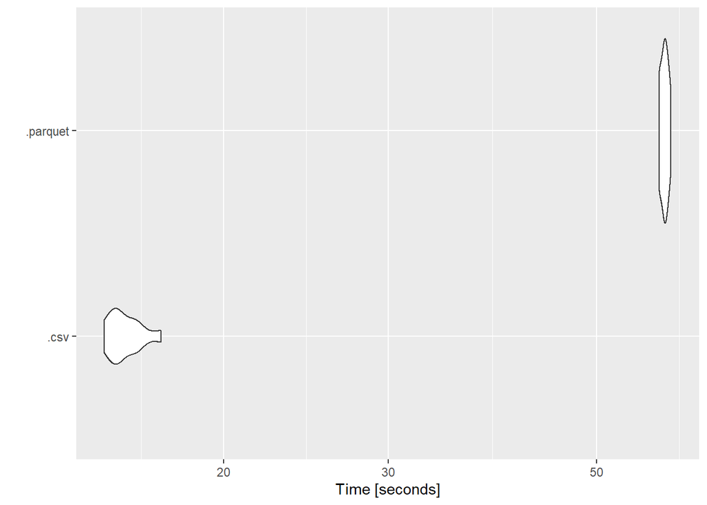

```r
mbm <- readRDS("mbmsparkload.rds")

autoplot(mbm)
```

Percebe-se que o arquivo em *.csv* foi carregado bem mais rápido que o arquivo em *.parquet* para o *spark*, resultado esse inesperado visto que o arquivo *.parquet* é menor e mais otimizado. Porém, após carregado, todas as manipulações e comandos rodam mais rapidamente no arquivo *.parquet* em relação ao arquivo *.csv*. Portanto, utilizarei somente o arquivo *.parquet* para os exercícios abaixo.

# **Questão 2: Preparando e modelando os dados.**

**Atenção: Elabore seus comandos dando preferência as funcionalidades do pacote `sparklyr`.**

## **a)** Faça uma breve análise exploratória dos dados (tabelas e gráficos) com base somente nas colunas existente nos arquivos de 1996. O dicionário das variaveis encontra-se no mesmo site do item **a)**, na parte de documentação. Corrija eventuais erros encontrados; por exemplo, na variavel sexo são apresentados rótulos distintos para um mesmo significado.

```r
dim <- sdf_dim(dfparquet)

glimpse <- glimpse(dfparquet)
```

```
## Rows: ??
## Columns: 21
## Database: spark_connection
## $ contador   <chr> "1", "2", "3", "4", "5", "6", "7", "8", "9", "10", "11", "1…
## $ LOCNASC    <chr> "1", "1", "1", "1", "1", "1", "1", "1", "1", "1", "1", "1",…
## $ CODMUNNASC <chr> "2922003", "2922003", "3205200", "3200102", "3204559", "320…
## $ IDADEMAE   <chr> "19", "18", "99", "30", "22", "27", "36", "25", "21", "25",…
## $ ESTCIVMAE  <chr> NA, NA, NA, NA, NA, NA, NA, NA, NA, NA, NA, NA, NA, NA, NA,…
## $ ESCMAE     <chr> "8", "7", "9", "6", "6", "6", "6", "7", "6", "6", "6", "6",…
## $ CODOCUPMAE <chr> NA, NA, NA, NA, NA, NA, NA, NA, NA, NA, NA, NA, NA, NA, NA,…
## $ QTDFILVIVO <chr> NA, NA, "03", "02", "00", "0", "01", "0", "0", "01", "02", …
## $ QTDFILMORT <chr> NA, NA, NA, "00", "00", NA, "00", NA, NA, "00", NA, NA, "00…
## $ CODMUNRES  <chr> "3204054", "3204054", "3205101", "3205101", "3205101", "320…
## $ GESTACAO   <chr> "5", "5", "5", "5", "5", "5", "5", "5", "5", "5", "5", "5",…
## $ GRAVIDEZ   <chr> "1", "1", "1", "1", "1", "1", "1", "1", "1", "1", "1", "1",…
## $ PARTO      <chr> "2", "2", "2", "2", "1", "2", "2", "2", "2", "1", "2", "1",…
## $ CONSULTAS  <chr> "4", "4", "9", "4", "8", "4", "4", "4", "4", "1", "1", "1",…
## $ DTNASC     <chr> "16121996", "16121996", "28041996", "05121996", "11121996",…
## $ SEXO       <chr> "1", "1", "2", "2", "1", "2", "1", "2", "2", "2", "2", "2",…
## $ APGAR1     <chr> "09", "09", "08", "10", "05", "09", "09", "09", "08", "09",…
## $ APGAR5     <chr> "09", "09", "09", "10", "07", "10", "09", "10", "09", "10",…
## $ RACACOR    <chr> NA, NA, NA, NA, NA, NA, NA, NA, NA, NA, NA, NA, NA, NA, NA,…
## $ PESO       <chr> "3250", "3250", "3300", "2690", "2400", "3770", "3130", "37…
## $ CODANOMAL  <chr> NA, NA, NA, NA, NA, NA, NA, NA, NA, NA, NA, NA, NA, NA, NA,…
```

```r
na <- dfparquet %>%
  summarise_all(~sum(as.integer(is.na(.)))) %>%
  collect()

summary <- sdf_describe(dfparquet) %>%
  collect ()

###dfparquet %>%
###  group_by(SEXO) %>%
###  tally()

dfparquet <- dfparquet %>%
  mutate(SEXO = case_when(SEXO == 'I' ~ 0,
                          SEXO == 0 ~ 0,
                          SEXO == 9 ~ 0,
                          SEXO == 'F' ~ 2,
                          SEXO == 2 ~ 2,
                          SEXO == 1 ~ 1,
                          SEXO == 'M' ~ 1))
dfparquet <- dfparquet %>%
  mutate(SEXO = ifelse(SEXO == 0,NA,SEXO))

###dfparquet %>%
###  group_by(SEXO) %>%
###  tally()

###dfparquet %>%
###  group_by(LOCNASC) %>%
###  tally()

dfparquet <- dfparquet %>%
  mutate(LOCNASC = ifelse(LOCNASC == 9 ,NA,LOCNASC))

###dfparquet %>%
###  group_by(ESTCIVMAE) %>%
###  tally()

###dfparquet %>%
###  group_by(ESCMAE) %>%
###  tally() %>%
###  print(n = Inf)

dfparquet <- dfparquet %>%
  mutate(ESCMAE = ifelse(ESCMAE == 9 | ESCMAE == 8 | ESCMAE == 7 | ESCMAE == 6 | ESCMAE == 0,NA,ESCMAE))

###dfparquet %>%
###  group_by(GESTACAO) %>%
###  tally()

###dfparquet %>%
###  group_by(GRAVIDEZ) %>%
###  tally()

###dfparquet %>%
###  group_by(PARTO) %>%
###  tally()

###dfparquet %>%
###  group_by(CONSULTAS) %>%
###  tally()

###dfparquet %>%
###  group_by(APGAR1) %>%
###  tally() %>%
###  print(n = Inf)

dfparquet <- dfparquet %>%
  mutate(APGAR1 = case_when(APGAR1 == '07' ~ '07',
                            APGAR1 == '01' ~ '01',
                            APGAR1 == '.' ~ NA,
                            APGAR1 == '08' ~ '08',
                            APGAR1 == '09' ~ '09',
                            APGAR1 == '8' ~ '08',
                            APGAR1 == '10' ~ '10',
                            APGAR1 == '0' ~ '00',
                            APGAR1 == '9' ~ '09',
                            APGAR1 == '05' ~ '05',
                            APGAR1 == '06' ~ '06',
                            APGAR1 == '<e8>' ~ NA,
                            APGAR1 == NA ~ NA,
                            APGAR1 == '03' ~ '03',
                            APGAR1 == '7' ~ '07',
                            APGAR1 == '04' ~ '04',
                            APGAR1 == '00' ~ '00',
                            APGAR1 == '--' ~ NA,
                            APGAR1 == '..' ~ NA,
                            APGAR1 == '99' ~ NA,
                            APGAR1 == '02' ~ '02'
                            ))

###dfparquet %>%
###  group_by(APGAR1) %>%
###  tally() %>%
###  print(n = Inf)

###dfparquet %>%
###  group_by(APGAR5) %>%
###  tally() %>%
###  print(n = Inf)

dfparquet <- dfparquet %>%
  mutate(APGAR5 = case_when(APGAR5 == '07' ~ '07',
                            APGAR5 == '01' ~ '01',
                            APGAR5 == '.' ~ NA,
                            APGAR5 == '08' ~ '08',
                            APGAR5 == '\u0017' ~ NA,
                            APGAR5 == '09' ~ '09',
                            APGAR5 == '8' ~ '08',
                            APGAR5 == '10' ~ '10',
                            APGAR5 == '0' ~ '00',
                            APGAR5 == '9' ~ '09',
                            APGAR5 == '4' ~ '04',
                            APGAR5 == '05' ~ '05',
                            APGAR5 == '06' ~ '06',
                            APGAR5 == '5' ~ '05',
                            APGAR5 == NA ~ NA,
                            APGAR5 == '03' ~ '03',
                            APGAR5 == '04' ~ '04',
                            APGAR5 == '00' ~ '00',
                            APGAR5 == '--' ~ NA,
                            APGAR5 == '0-' ~ '00',
                            APGAR5 == '..' ~ NA,
                            APGAR5 == '99' ~ NA,
                            APGAR5 == '02' ~ '02',
                            APGAR5 == '39' ~ NA
  ))

###dfparquet %>%
###  group_by(RACACOR) %>%
###  tally() %>%
###  print(n = Inf)

dfparquet <- dfparquet %>%
  mutate(RACACOR = case_when(RACACOR == 3 ~ 3,
                             RACACOR == 9 ~ NA,
                             RACACOR == 2 ~ 2,
                             RACACOR == 4 ~ 4,
                             RACACOR == 1 ~ 1,
                             RACACOR == 5 ~ 5,
                             RACACOR == NA ~ NA

  ))

###dfparquet %>%
###  group_by(IDADEMAE) %>%
###  tally() %>%
###  print(n = Inf)

dfparquet <- dfparquet %>%
  mutate(IDADEMAE = ifelse(IDADEMAE == '00' | IDADEMAE == '99', NA, IDADEMAE))
```

```r
sexoraca <- dfparquet %>%
  group_by(RACACOR,SEXO) %>%
  filter(RACACOR %in% 1:5 & SEXO %in% 1:2) %>%
  tally() %>%
  collect()

tipolocal <- dfparquet %>%
  group_by(LOCNASC,PARTO) %>%
  filter(LOCNASC %in% 1:3 & PARTO %in% 1:2) %>%
  tally() %>%
  collect ()

diasemana <-dfparquet %>%
  select(DTNASC) %>%
  collect()

diasemana <- as.vector(diasemana$DTNASC)
diasemana <- lubridate::wday(lubridate::dmy(diasemana),  label = TRUE)
diasemana <- factor(diasemana)

diasemana1 <- diasemana

histograma <- dfparquet %>%
  select(PESO) %>%
  filter(PESO <= '7.500') %>%
  dbplot_histogram(PESO, bins = 15)

estcivil <- dfparquet %>%
  group_by(ESTCIVMAE) %>%
  filter(ESTCIVMAE %in% 1:4) %>%
  tally() %>%
  collect()

correlacao1 <- dfparquet %>%
  select(IDADEMAE,PESO) %>%
  filter(PESO <= '7.500') %>%
  mutate(IDADEMAE = as.integer(IDADEMAE)) %>%
  mutate(PESO = as.numeric(PESO)) %>%
  collect()

correlacao1 <- correlate(correlacao1)
correlacao1 <- as.numeric(correlacao1$IDADEMAE[2])

diasemanatibble <- as_tibble(diasemana1)
diasemanatibble <- diasemanatibble %>%
  mutate(value = ifelse(value == '"s\u00e1b"', 'sáb', value)) %>%
  group_by(value) %>%
  tally ()
diasemanatibble <- diasemanatibble %>%
  mutate(value = case_when(value == 1 ~ "dom",
                           value == 2 ~ "seg",
                           value == 3 ~ "ter",
                           value == 4 ~ "qua",
                           value == 5 ~ "qui",
                           value == 6 ~ "sex",
                           value == 7 ~ "sab"

  ))

dia_freq <- diasemanatibble$n
dia_freq <- dia_freq[1:7]

#coeficiente de variação dos dias da semana:
vardiasem <- sd(dia_freq)/mean(dia_freq)*100

tipolocal <- tipolocal %>%
  mutate(LOCNASC = case_when(LOCNASC == 1 ~ "Hospital",
                           LOCNASC == 2 ~ "Outro Estab Saúde",
                           LOCNASC == 3 ~ "Domicílio")) %>%
  mutate(PARTO = case_when(PARTO == 1 ~ "Vaginal",
                           PARTO == 2 ~ "Cesáreo"))


colnames(tipolocal) <- c("Local de Nascimento","Tipo de parto","Contagem")

estcivil <- estcivil %>%
  mutate(ESTCIVMAE = case_when(ESTCIVMAE == 1 ~ "Solteira",
                           ESTCIVMAE == 2 ~ "Casada",
                           ESTCIVMAE == 3 ~ "Viúva",
                           ESTCIVMAE == 4 ~ "Separado judicialmente/Divorciado"))

colnames(estcivil) <- c("Estado civil da mãe","Contagem")

peso <- dfparquet %>%
  select(PESO) %>%
  filter(PESO <= '7.500')%>%
  collect()

peso$PESO <- as.numeric(peso$PESO)
peso <- peso$PESO

#coeficiente de variação:
cvpeso <- sd(peso,na.rm=TRUE)/mean(peso,na.rm=TRUE)*100

#Coeficiente de assimetria de pearson:
AS<-3*(mean(peso,na.rm=TRUE) - median(peso,na.rm=TRUE))/sd(peso,na.rm=TRUE)

#coef momento de assimetria
cma <- skewness(peso, na.rm = TRUE, method = "moment", l.moment.method = "unbiased")

#Coeficiente momento de curtose
cmc <- kurtosis(peso, na.rm = TRUE, method = "moment", l.moment.method = "unbiased")

medidaspeso <- c(min(peso,na.rm=TRUE),as.numeric(quantile(peso,na.rm=TRUE)[2]),
                 median(peso,na.rm=TRUE),mean(peso,na.rm=TRUE),
                 as.numeric(quantile(peso,na.rm=TRUE)[4]),max(peso,na.rm=TRUE),
                 IQR(peso,na.rm=TRUE),sd(peso,na.rm=TRUE),var(peso,na.rm=TRUE),
                 cvpeso,AS,cma,cmc)

labels <- c("Mínimo","1º Quartil","Mediana","Média","3º Quartil","Máximo",
            "Distância Interquartílica","Desvio padrão","Variância",
            "Coeficiente de Variação","Coeficiente de assimetria de pearson",
            "Coeficiente momento de assimetria","Coeficiente momento de curtose")

labels <- as_tibble(labels)

labels$est <- NA

labels$est <- medidaspeso

colnames(labels) <- c("Estatísticas","Valores")

summary <- summary %>%
  select(summary,IDADEMAE,APGAR1,APGAR5,PESO)

sexoraca <- sexoraca %>%
  mutate(RACACOR = case_when(RACACOR == 1 ~ "Branca",
                             RACACOR == 2 ~ "Preta",
                             RACACOR == 3 ~ "Amarela",
                             RACACOR == 4 ~ "Parda",
                             RACACOR == 5 ~ "Indígena"
                             )) %>%
  mutate(SEXO = case_when(SEXO == 1 ~ "Masculino",
                          SEXO == 2 ~ "Feminino"))

colnames(sexoraca) <- c("Raça/Cor","Sexo","Contagem")
```